# Datasets for examples and lab

Author

Casey O’Hara

Published

February 15, 2024

```r
library(tidyverse)
library(here)
library(tidymodels)
library(GGally)
library(jtools)
library(AICcmodavg)
```

# Overview

# Sheep data

Allison’s original example used a fictional dataset of male sheep success in finding a mate, as a function of their weight. Let’s recreate that.

```r
set.seed(12)
sheep_mate_df <- data.frame(success = sample(c(1, 0), 67, replace = TRUE)) %>%
  mutate(weight = rnorm(mean = 140, sd = 15, n = n()) + 30 * success,
         weight = round(weight, 1))

knitr::kable(head(sheep_mate_df))
```

| success | weight |
| --- | --- |
| 0 | 150.2 |
| 0 | 150.8 |
| 0 | 148.5 |
| 1 | 165.6 |
| 1 | 195.2 |
| 0 | 147.9 |

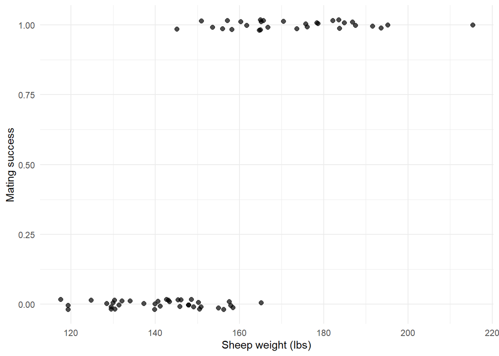

```r
ggplot(sheep_mate_df, aes(x = weight, y = success)) +
  geom_jitter(size = 2, alpha = .7, height = .02, width = 0) +
  theme_minimal() +
  labs(x = 'Sheep weight (lbs)',
       y = 'Mating success')
```

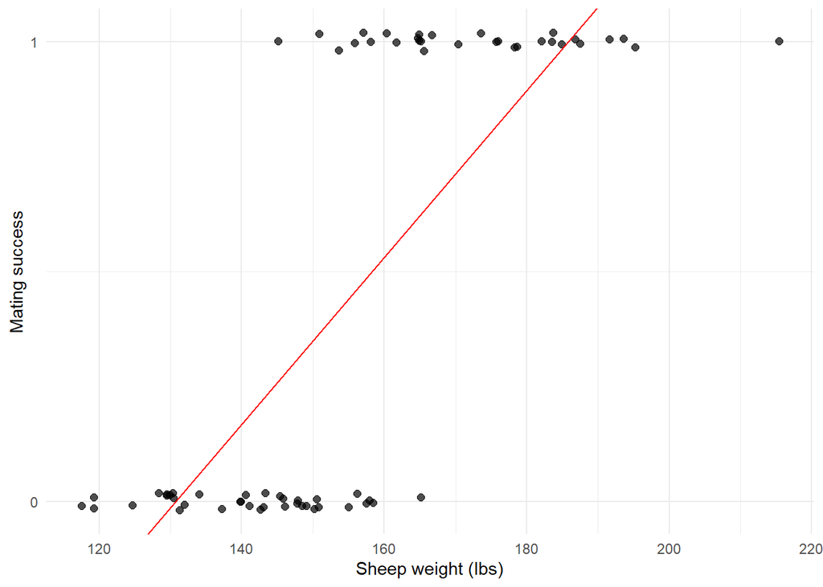

```r
lm1 <- lm(success ~ weight, data = sheep_mate_df)
ggplot(sheep_mate_df, aes(x = weight, y = success)) +
  geom_jitter(size = 2, alpha = .7, height = .02, width = 0) +
  geom_abline(intercept = lm1$coefficients[1],
              slope = lm1$coefficients[2], color = 'red') +
  theme_minimal() +
  scale_y_continuous(breaks = c(0, 1)) +
  labs(x = 'Sheep weight (lbs)',
       y = 'Mating success')
```

linear model not great for predicting categorical values.

## Binary logistic regression

Plotting as a straight line, the y axis is essentially $\ln\left(\frac{p_M}{1-p_M}\right)$

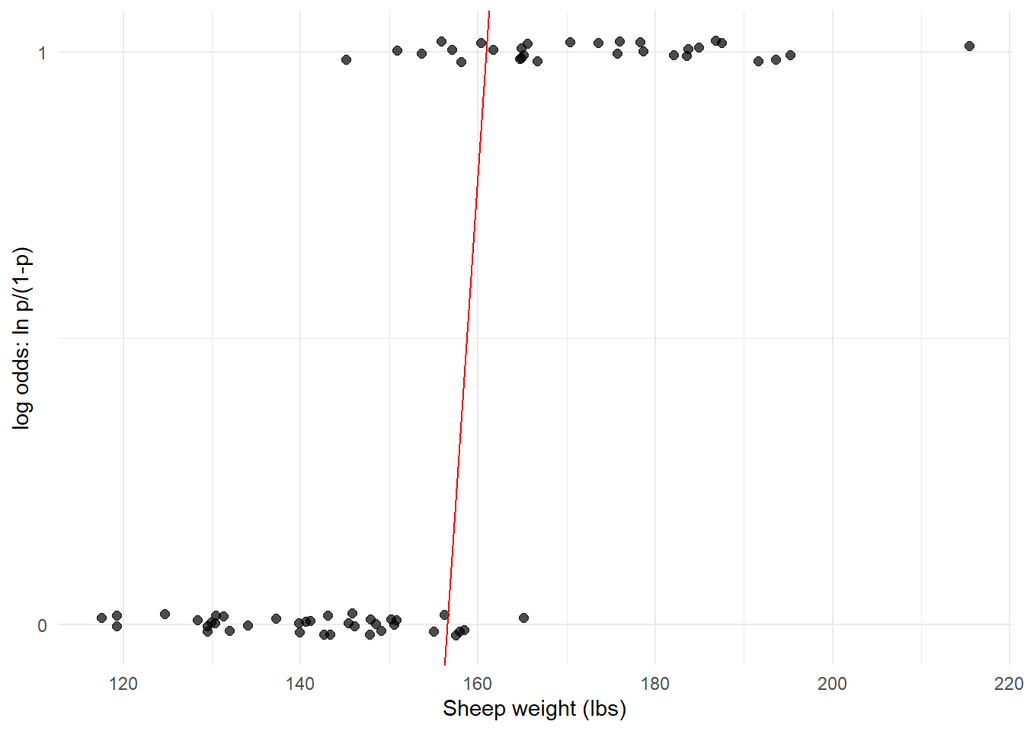

```r
blr1 <- glm(success ~ weight, data = sheep_mate_df, family = 'binomial')

ggplot(sheep_mate_df, aes(x = weight, y = success)) +
  geom_jitter(size = 2, alpha = .7, height = .02, width = 0) +
  geom_abline(intercept = blr1$coefficients[1],
              slope = blr1$coefficients[2], color = 'red') +
  theme_minimal() +
  scale_y_continuous(breaks = c(0, 1)) +
  labs(x = 'Sheep weight (lbs)',
       y = 'log odds: ln p/(1-p)')
```

Y axis labeled with log odds

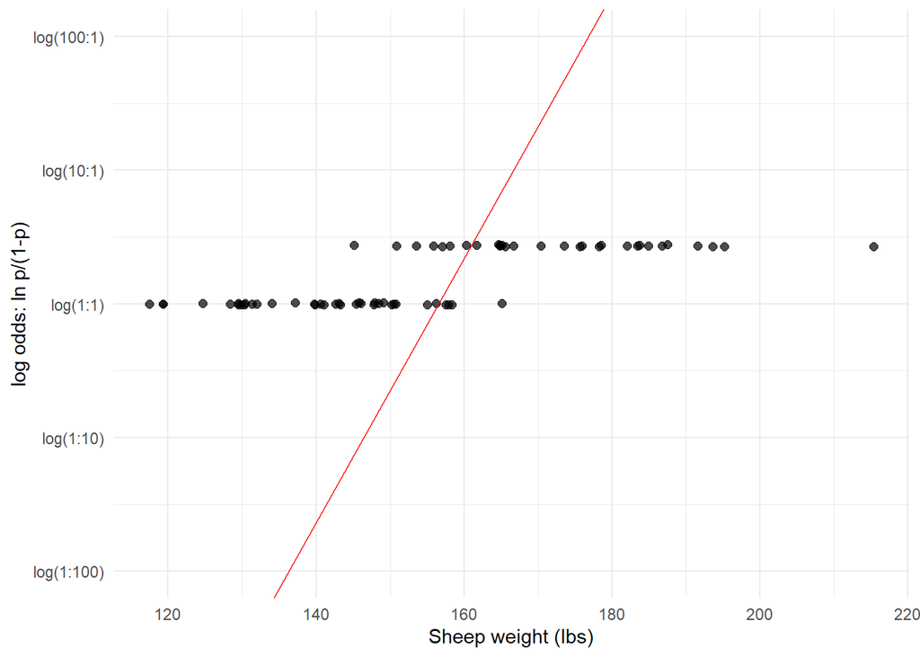

```r
logodds_breaks <- log(c(.01, .1, 1, 10, 100))
logodds_labels <- c('log(1:100)', 'log(1:10)', 'log(1:1)', 'log(10:1)', 'log(100:1)')
ggplot(sheep_mate_df, aes(x = weight, y = success)) +
  geom_jitter(size = 2, alpha = .7, height = .02, width = 0) +
  geom_abline(intercept = blr1$coefficients[1],
              slope = blr1$coefficients[2], color = 'red') +
  theme_minimal() +
  scale_y_continuous(breaks = logodds_breaks,
                     labels = logodds_labels,
                     limits = range(logodds_breaks)) +
  labs(x = 'Sheep weight (lbs)',
       y = 'log odds: ln p/(1-p)')
```

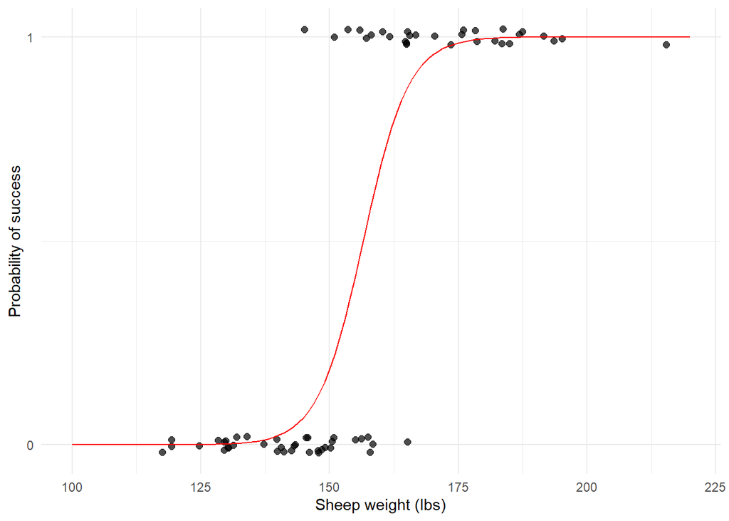

```r
pred_blr1 <- data.frame(weight = 100:220) %>%
  mutate(prob_success = predict(blr1, ., type = 'response'))

ggplot(sheep_mate_df, aes(x = weight, y = success)) +
  geom_jitter(size = 2, alpha = .7, height = .02, width = 0) +
  geom_line(data = pred_blr1, aes(y = prob_success), color = 'red') +
  theme_minimal() +
  scale_y_continuous(breaks = c(0, 1),
                     labels = c(0, 1)) +
  labs(x = 'Sheep weight (lbs)',
       y = 'Probability of success')
```

# Possum data

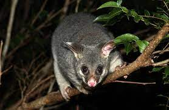

## Metadata:

**Content:** From the DAAG R package: “The possum data frame consists of nine morphometric measurements on each of 104 mountain brushtail possums, trapped at seven sites from Southern Victoria to central Queensland.”

**Original Source of dataset:** Lindenmayer, D. B., Viggers, K. L., Cunningham, R. B., and Donnelly, C. F. 1995. Morphological variation among columns of the mountain brushtail possum, Trichosurus caninus Ogilby (Phalangeridae: Marsupiala). Australian Journal of Zoology 43: 449-458.

Downloaded 2024-02-15 from https://www.kaggle.com/datasets/abrambeyer/openintro-possum

**Columns:**

| Column name | Description |
| --- | --- |
| `case` | observation number |
| `site` | The site number where the possum was trapped |
| `Pop` | Population, either Vic (Victoria) or other (New South Wales or Queensland) |
| `sex` | Gender, either m (male) or f (female) |
| `age` | Age |
| `hdlngth` | Head length, in mm |
| `skullw` | Skull width, in mm |
| `totlngth` | Total length, in cm |
| `taill` | Tail length, in cm |
| `footlgth` | foot length |
| `earconch` | ear conch length |
| `eye` | distance from medial canthus to lateral canthus of right eye |
| `chest` | chest girth in cm |
| `belly` | belly girth in cm |

## Analysis

Let’s create a model to predict sex of a mountain brushtail possum from other observable characteristics. This would be useful in, say, a situation where a researcher used a camera trap to observe visible characteristics but was unable to observe sex. Recode sex to indicate 0 for female (reference value) and 1 for male

```r
possums_df <- read_csv(here('data/possums/possum_data.csv'),
                       show_col_types = FALSE) %>%
  janitor::clean_names() %>%
  mutate(sex = factor(sex))

# levels(possums_df$sex)
poss2_df <- possums_df %>%
  mutate(sex = as.numeric(sex) - 1)
```

### check models

This model includes easily observable variables as potential predictors.

[figure not shown]

```r
f1 <- sex ~ hdlngth + totlngth # + pop + taill + eye

possum_lr1 <- lm(formula = sex ~ hdlngth + totlngth,
                 data = poss2_df)

ggplot(poss2_df, aes(x = totlngth, y = sex)) +
  geom_jitter(height = .05, width = 0) +
  geom_abline(intercept = possum_lr1$coefficients[1],
              slope = possum_lr1$coefficients[3]) +
  theme_minimal() +
  scale_y_continuous(breaks = c(0, 1), labels = c('1 = Female', '2 = Male')) +
  labs(x = 'Head length (cm)',
       y = 'Sex')
```

```r
possum_blr1 <- glm(formula = f1,
                   data = possums_df,
                   family = "binomial")

# possum_blr1

summary(possum_blr1)
```

```
Call:
glm(formula = f1, family = "binomial", data = possums_df)

Coefficients:
            Estimate Std. Error z value Pr(>|z|)
(Intercept) -4.24721    5.78126  -0.735  0.46255
hdlngth      0.27960    0.09542   2.930  0.00339 **
totlngth    -0.24389    0.07705  -3.165  0.00155 **
---
Signif. codes:  0 '***' 0.001 '**' 0.01 '*' 0.05 '.' 0.1 ' ' 1

(Dispersion parameter for binomial family taken to be 1)

    Null deviance: 141.04  on 103  degrees of freedom
Residual deviance: 127.99  on 101  degrees of freedom
AIC: 133.99

Number of Fisher Scoring iterations: 4
```

```r
# Get a tidy version w/ broom:
blr1_tidy <- broom::tidy(possum_blr1)
```

```r
blr1_fitted <- possum_blr1 %>%
  broom::augment(type.predict = "response")
```

[figure not shown]

```r
ggplot(data = blr1_fitted, aes(x = totlngth, y = .fitted)) +
  geom_point(aes(color = sex)) +
  # add geom_smooth to show general fit
  geom_smooth(aes(color = sex), se = FALSE) +
  labs(x = "Flipper length (mm)",
       y = "Probability of outcome male")
```